# **An Analysis of New York City's Motor Vehicle Collisions**

**Summer 2025 Data Science Project**

- William Chiang
- Vikram Raja
- Daniel Xu
- Bea Ybanez

**Contributions:**

A: Project idea - All. William found the dataset. Vikram, Daniel, and Bea worked on brain storming questions that could be answered by this dataset.

B: Dataset Curation and Preprocessing - Vikram worked on importing as well as setting up the dataframes he would need for his data exploration. Daniel, William, and Bea also set up the dataframes each needed for their own data explorations.

C: Data Exploration and Summary Statistics - All. Vikram explored Deadliest Streets in NY, Daniel explored Weekday vs Weekend Injuries, William explored Rush Hour Crashes, and Bea explored Average Injuries by Hour.

D: ML Algorithm Design/Development - All. Bea and Vikram provided ideas for the ML algorithm design. Daniel did most of the development. William did most of the write up.

E: ML Algorithm Training and Test Data Analysis - Daniel worked on the ML training and analysis code.

F: Visualization, Result Analysis, Conclusion - Daniel worked on making the visualization. Both Daniel and William worked on the analysis and conclusion write up.

G: Final Tutorial Report Creation - Daniel and William recorded the Header with contributions. Vikram wrote up the Introduction. Bea reorganized Checkpoint 2 to fit The Data curation and Exploratory data analysis sections, and redeveloped the standardized testing for each data exploration. Vikram and Bea worked on creating the GitHub page submission.

# **Introduction**

In America, motor vehicle collisions are one of the leading causes of death. When one enters the roads of America, whether they are behind the wheel or not, the risks are often overlooked. Using the roads is a modern-day necessity, however, many people are unaware of how to mitigate risks. By analyzing traffic accident data, our team hopes to identify: **"What are key motor vehicle collision risk factors that everyday people can avoid?"** With this knowledge, drivers can make educated decisions to protect themselves and others on the road.

# **Data Curation**

For this project, we will be using the dataset from [City of New York's Local Government Data on Motor Vehicle Collisions - Crashes](https://catalog.data.gov/dataset/motor-vehicle-collisions-crashes), which we've saved as "Motor_Vehicles_Collisions.csv." This file contains police-reported motor vehicle collisions in NYC involving injuries or deaths starting from 2014 to the present day.

**Imports**  
The main library we are using is Pandas, an open-source software library for data manipulation and analysis.

We also widely used SciPy for statistical functions for data analysis.

```python
import pandas as pd
import string
import math
import matplotlib.pyplot as plt
import seaborn as sns

from datetime import datetime
from scipy import stats
from statsmodels.stats.proportion import proportions_ztest
from scipy.stats import f_oneway
from scipy.stats import ttest_ind
```

**Transform Data**  
We downloaded the csv file from the website and imported it into our project as crashes_df. Then each of us copied/manipulated the dataset for our individual needs for analysis.

```python
# Loading dataset
crashes_df = pd.read_csv('Motor_Vehicles_Collisions.csv', low_memory=False)

# Converting dates and times
crashes_df['CRASH DATE'] = pd.to_datetime(crashes_df['CRASH DATE'], errors='coerce')
crashes_df['CRASH TIME'] = pd.to_datetime(crashes_df['CRASH TIME'], errors='coerce', format='%H:%M')
crashes_df['CRASH HOUR'] = crashes_df['CRASH TIME'].dt.hour

#####
# SETTING UP THE SPECIFIC DATAFRAMES FOR ANALYSIS
#####

# 1. Deadliest Streets in NY -Vikram
deadly_df = crashes_df[['NUMBER OF PERSONS KILLED', 'ON STREET NAME']].copy()

# 2. Weekday vs Weekend Injuries/Deaths -Daniel
injury_day_df = crashes_df.dropna(subset=['NUMBER OF PERSONS INJURED', 'NUMBER OF PERSONS KILLED']).copy()
injury_day_df['DAY_OF_WEEK'] = injury_day_df['CRASH DATE'].dt.dayofweek
injury_day_df['IS_WEEKEND'] = injury_day_df['DAY_OF_WEEK'] >= 5

# 3. Rush Hour Crashes -William
rush_hour_df = crashes_df.dropna(subset=['CRASH HOUR']).copy()
rush_hour_df['CRASH HOUR'] = pd.to_datetime(rush_hour_df['CRASH TIME'], format = '%H:%M').dt.hour
rush_hour_df['IS_RUSH_HOUR'] = rush_hour_df['CRASH HOUR'].between(7, 9) | rush_hour_df['CRASH HOUR'].between(16, 18)

# 4. Average Injuries by Hour -Bea
crashes_df['NUMBER OF PERSONS INJURED'] = pd.to_numeric(crashes_df['NUMBER OF PERSONS INJURED'], errors='coerce')
crashes_df = crashes_df.dropna(subset=['CRASH HOUR', 'NUMBER OF PERSONS INJURED'])
```

# **Exploratory Data Analysis**

```python
mask = deadly_df['NUMBER OF PERSONS KILLED'] != 0.0
mask &= deadly_df['NUMBER OF PERSONS KILLED'].notnull()
mask &= deadly_df['ON STREET NAME'] != 0.0
mask &= deadly_df['ON STREET NAME'].notnull()
filtered = deadly_df[mask].copy()

filtered['STREET NAME'] = (filtered['ON STREET NAME'].str.strip().str.lower())
crashes_normdf= filtered[['STREET NAME', 'NUMBER OF PERSONS KILLED' ]]

summed_deaths = (crashes_normdf .groupby('STREET NAME', as_index=False).agg({'NUMBER OF PERSONS KILLED': 'sum'}))

summed_deaths = summed_deaths.sort_values(by='NUMBER OF PERSONS KILLED', ascending=False)
summed_deaths = summed_deaths.reset_index(drop=True)

summed_deaths_top=summed_deaths.head(10)
```

**Plotting**

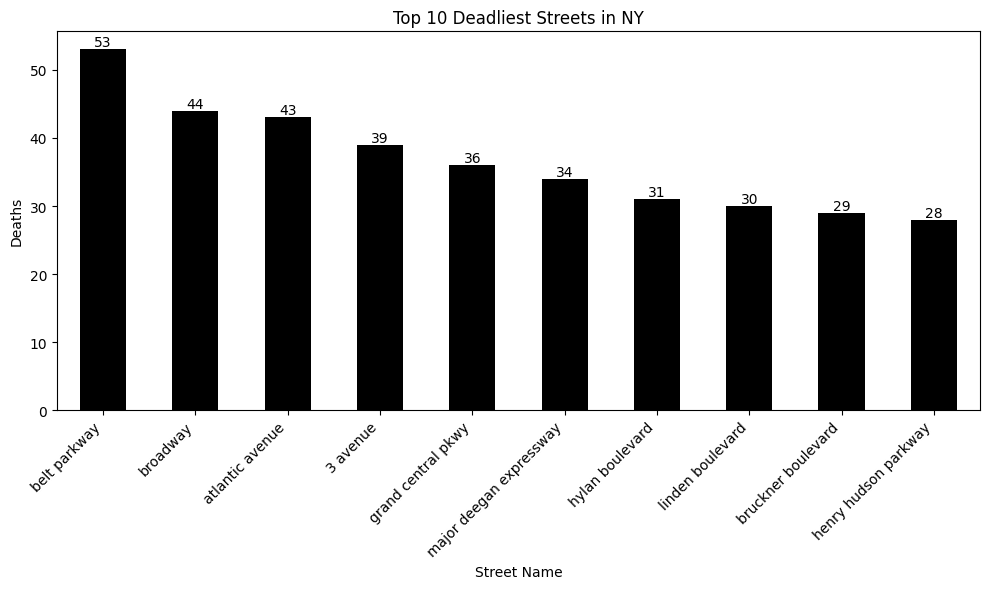

```python
# 1.
ax = summed_deaths_top.plot.bar(
    x='STREET NAME',
    y='NUMBER OF PERSONS KILLED',
    figsize=(10,6),
    legend=False,
    color='black'
)

plt.subplots_adjust(left=0.1, right=0.95, top=0.9, bottom=0.25)
ax.set_xlabel('Street Name')
ax.set_ylabel('Deaths')
ax.set_title('Top 10 Deadliest Streets in NY')
plt.xticks(rotation=45, ha='right')

for p in ax.patches:
    ax.annotate(
        str(int(p.get_height())),
        (p.get_x() + p.get_width() / 2, p.get_height()),
        ha='center', va='bottom'
    )

plt.tight_layout()
plt.show()
```

**Testing**

```python
print("\n=== Hypothesis Test: Top 10 vs Other Streets (T-Test) ===")
print("Null Hypothesis: No difference in mean deaths between top 10 streets and other streets.")
print("Alternative Hypothesis: Top 10 streets have a higher mean number of deaths.")

# T-test
top_10 = summed_deaths_top['NUMBER OF PERSONS KILLED']
others = summed_deaths[~summed_deaths['STREET NAME'].isin(summed_deaths_top['STREET NAME'])]['NUMBER OF PERSONS KILLED']
t_stat, p_val = ttest_ind(top_10, others.sample(n=1000, random_state=69))

# Key stats
print(f"\nTest Used: Two-sample T-test (one-tailed)")
print(f"Top 10 mean: {top_10.mean():.2f}")
print(f"Other streets mean: {others.mean():.2f}")
print(f"T-statistic: {t_stat:.2f}")
print(f"P-value: {p_val:.6f}")
print("Significance Level: 0.05")

# Decision
if p_val < 0.05:
    print("Decision: REJECT the null hypothesis.")
    print(f"Conclusion: Top 10 streets are statistically deadlier — approximately {top_10.mean() / others.mean():.1f}x higher mean deaths.")
else:
    print("Decision: FAIL TO REJECT the null hypothesis.")
    print("Conclusion: No statistically significant difference in deaths between top 10 and other streets.")
```

[output not shown]

2. **Weekday vs Weekend Injuries -Daniel**  
   This analysis compares the number of injuries resulting from crashes on weekdays versus weekends. The data is filtered and categorized into two groups using day-of-week values. A boxplot is used for visualization. A one-tailed t-test is used to determine if weekday crashes result in more injuries compared to weekend crashes.

```python
# Split injury data into two groups: weekday vs weekend
weekday_injuries = injury_day_df[injury_day_df['IS_WEEKEND'] == False]['NUMBER OF PERSONS INJURED']
weekend_injuries = injury_day_df[injury_day_df['IS_WEEKEND'] == True]['NUMBER OF PERSONS INJURED']

print(f"Weekday Injuries: {weekday_injuries}")
print(f"Weekend Injuries: {weekend_injuries}")
```

```
Weekday Injuries: 2          1.0
3          0.0
4          0.0
5          0.0
6          0.0
          ...
2186463    2.0
2186464    0.0
2186465    0.0
2186466    0.0
2186467    2.0
Name: NUMBER OF PERSONS INJURED, Length: 1627311, dtype: float64
Weekend Injuries: 0          2.0
1          1.0
9          0.0
24         1.0
26         0.0
          ...
2186438    1.0
2186445    0.0
2186447    1.0
2186456    0.0
2186460    0.0
Name: NUMBER OF PERSONS INJURED, Length: 559120, dtype: float64
```

**Plotting**

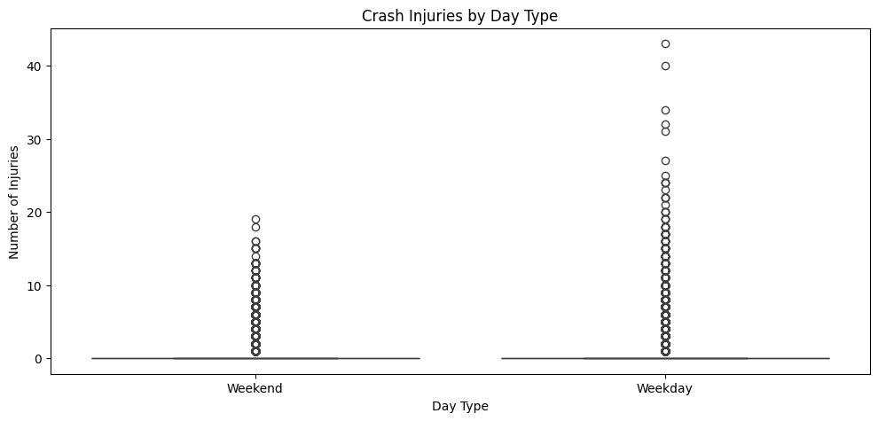

```python
# 2.
injury_day_df['DAY_TYPE'] = injury_day_df['IS_WEEKEND'].map({True: 'Weekend', False: 'Weekday'})
plt.figure(figsize=(11, 6), dpi=100)
plt.subplots_adjust(left=0.1, right=0.94, top=0.9, bottom=0.25)
sns.boxplot(x = 'DAY_TYPE', y = 'NUMBER OF PERSONS INJURED', data = injury_day_df)
plt.title('Crash Injuries by Day Type')
plt.xlabel('Day Type')
plt.ylabel('Number of Injuries')
plt.show()
```

**Testing**

```python
# Use a T-test because we are comparing two group means.
# One-tailed because we want to see if weekday crashes result in MORE injuries than weekend crashes (average).
print("\n=== Hypothesis Test: Weekday vs Weekend Injuries (T-Test) ===")
print("Null Hypothesis: No difference in mean injuries between weekday and weekend crashes.")
print("Alternative Hypothesis: Weekday crashes result in more injuries than weekend crashes.")

# T-test
weekday_injuries = injury_day_df[injury_day_df['IS_WEEKEND'] == False]['NUMBER OF PERSONS INJURED']
weekend_injuries = injury_day_df[injury_day_df['IS_WEEKEND'] == True]['NUMBER OF PERSONS INJURED']
t_stat, p_val = stats.ttest_ind(weekday_injuries, weekend_injuries, alternative='greater')

# Key stats
print(f"\nTest Used: Two-sample T-test (one-tailed)")
print(f"Weekday mean: {weekday_injuries.mean():.2f}")
print(f"Weekend mean: {weekend_injuries.mean():.2f}")
print(f"T-statistic: {t_stat:.2f}")
print(f"P-value: {p_val:.6f}")
print("Significance Level: 0.05")

# Decision
if p_val < 0.05:
    print("Decision: REJECT the null hypothesis.")
    print("Conclusion: Weekday crashes cause statistically more injuries than weekend crashes.")
else:
    print("Decision: FAIL TO REJECT the null hypothesis.")
    print("Conclusion: No statistically significant difference between weekday and weekend injury rates.")
```

```
=== Hypothesis Test: Weekday vs Weekend Injuries (T-Test) ===
Null Hypothesis: No difference in mean injuries between weekday and weekend crashes.
Alternative Hypothesis: Weekday crashes result in more injuries than weekend crashes.

Test Used: Two-sample T-test (one-tailed)
Weekday mean: 0.31
Weekend mean: 0.35
T-statistic: -37.02
P-value: 1.000000
Significance Level: 0.05
Decision: FAIL TO REJECT the null hypothesis.
Conclusion: No statistically significant difference between weekday and weekend injury rates.
```

```python
# find total number of rush hour crashes and total crashes
rushCrash = rush_hour_df['IS_RUSH_HOUR'].sum()
totCrash = len(rush_hour_df)
```